# Survival on the Titanic: Analyzing Patterns and Building Predictive Models

Khoi Nguyen

## Introduction

The Titanic dataset will be use for this project to predict passenger survival based on key variables such as age, gender, passenger class, and fare through machine learning techniques. I chose this dataset because it is a well-known case study that provides a meaningful opportunity to apply data science and machine learning methods to a real-world scenario. The historical context and its structure have multiple flaws, allowing for exploring techniques like data cleaning, feature engineering, and predictive modeling. The dataset contains 891 records and 12 features, covering demographic information (Age, Sex), travel details (Pclass, Ticket, Fare, Cabin), and family-related attributes (SibSp, Parch), with Survived as the target variable. I will begin the project by conducting exploratory data analysis to understand patterns in the data and identify missing values, particularly in Age, Cabin, and Embarked, which I will address through imputation techniques. In the preprocessing stage, I will convert categorical variables (such as Sex, Pclass, and Embarked) into factors, normalize numerical features like Age and Fare, and engineer additional features, such as a binary variable indicating whether a passenger has cabin information. The dataset will then be split into training and testing subsets using stratified sampling to maintain the distribution of the target variable. In constructing the predictive models, a range of machine learning algorithms will be applied, including Logistic Regression, K-Nearest Neighbors (KNN), Decision Tree, and Random Forest. Each model will be evaluated using cross-validation and hyperparameter tuning to optimize performance. This project aims to discover which patterns and features contribute most to survival on the Titanic and gain hands-on experience with end-to-end machine learning workflows.

## Data

```r
titanic <- read.csv("titanic.csv")
```

The dataset consists of information on 891 passengers who were aboard the Titanic. It includes various features that describe each passenger, such as demographic details (age, sex), travel-related attributes (passenger class, ticket fare, and cabin assignment), family connections (number of siblings/spouses and parents/children aboard), and whether or not the passenger survived the disaster.

## Analysis/Methodology

The methodology of this project used a structured machine-learning pipeline applied to the Titanic dataset. Initially, exploratory data analysis will identify data types, patterns, and missing values, particularly in Age, Cabin, and Embarked variables. Data preprocessing included converting categorical variables (Sex, Pclass, Embarked, Survived, HasCabin) into factors and imputing missing values: Age will be filled using the median grouped by Sex and Pclass, Embarked was imputed with the actual data found on the web, and a binary feature was created for Cabin availability. The dataset will then be split into training and testing sets using stratified sampling to maintain the distribution of the target variable Survived. A preprocessing pipeline was implemented using the recipes package, which normalized numerical predictors and converted categorical predictors into dummy variables. Multiple classification models will be trained and tuned using 5-fold cross-validation, including logistic regression, k-nearest neighbors (KNN), decision tree, and random forest. Hyperparameter tuning was performed for KNN (k values), decision tree (complexity parameter), and random forest (mtry parameter). Model performance will be evaluated using the ROC metric, and variable importance plots will be generated to interpret key predictors of survival. The final model selection will be based on cross-validated performance before being applied to the test set for prediction.

### Data Exploration

```r
# 1. Provides a concise summary of the titanic data frame's structure and data types:
glimpse(titanic)
```

```
## Rows: 891
## Columns: 12
## $ PassengerId <int> 1, 2, 3, 4, 5, 6, 7, 8, 9, 10, 11, 12, 13, 14, 15, 16, 17,…
## $ Survived    <int> 0, 1, 1, 1, 0, 0, 0, 0, 1, 1, 1, 1, 0, 0, 0, 1, 0, 1, 0, 1…
## $ Pclass      <int> 3, 1, 3, 1, 3, 3, 1, 3, 3, 2, 3, 1, 3, 3, 3, 2, 3, 2, 3, 3…
## $ Name        <chr> "Braund, Mr. Owen Harris", "Cumings, Mrs. John Bradley (Fl…
## $ Sex         <chr> "male", "female", "female", "female", "male", "male", "mal…
## $ Age         <dbl> 22, 38, 26, 35, 35, NA, 54, 2, 27, 14, 4, 58, 20, 39, 14, …
## $ SibSp       <int> 1, 1, 0, 1, 0, 0, 0, 3, 0, 1, 1, 0, 0, 1, 0, 0, 4, 0, 1, 0…
## $ Parch       <int> 0, 0, 0, 0, 0, 0, 0, 1, 2, 0, 1, 0, 0, 5, 0, 0, 1, 0, 0, 0…
## $ Ticket      <chr> "A/5 21171", "PC 17599", "STON/O2. 3101282", "113803", "37…
## $ Fare        <dbl> 7.2500, 71.2833, 7.9250, 53.1000, 8.0500, 8.4583, 51.8625,…
## $ Cabin       <chr> "", "C85", "", "C123", "", "", "E46", "", "", "", "G6", "C…
## $ Embarked    <chr> "S", "C", "S", "S", "S", "Q", "S", "S", "S", "C", "S", "S"…
```

```r
# 2. Calculates the total number of missing values (NA) in the titanic data frame:
sum(is.na(titanic))
```

```
## [1] 177
```

```r
# 3. Provides descriptive statistics for each column in the sales data frame, including min, max, mean, median, quartiles, and counts for factors:
summary(titanic)
```

```
##   PassengerId       Survived          Pclass          Name
##  Min.   :  1.0   Min.   :0.0000   Min.   :1.000   Length:891
##  1st Qu.:223.5   1st Qu.:0.0000   1st Qu.:2.000   Class :character
##  Median :446.0   Median :0.0000   Median :3.000   Mode  :character
##  Mean   :446.0   Mean   :0.3838   Mean   :2.309
##  3rd Qu.:668.5   3rd Qu.:1.0000   3rd Qu.:3.000
##  Max.   :891.0   Max.   :1.0000   Max.   :3.000
##
##      Sex                 Age            SibSp           Parch
##  Length:891         Min.   : 0.42   Min.   :0.000   Min.   :0.0000
##  Class :character   1st Qu.:20.12   1st Qu.:0.000   1st Qu.:0.0000
##  Mode  :character   Median :28.00   Median :0.000   Median :0.0000
##                     Mean   :29.70   Mean   :0.523   Mean   :0.3816
##                     3rd Qu.:38.00   3rd Qu.:1.000   3rd Qu.:0.0000
##                     Max.   :80.00   Max.   :8.000   Max.   :6.0000
##                     NA's   :177
##     Ticket               Fare           Cabin             Embarked
##  Length:891         Min.   :  0.00   Length:891         Length:891
##  Class :character   1st Qu.:  7.91   Class :character   Class :character
##  Mode  :character   Median : 14.45   Mode  :character   Mode  :character
##                     Mean   : 32.20
##                     3rd Qu.: 31.00
##                     Max.   :512.33
##
```

```r
# 4. Calculates the number of missing values (NA) in each column of the titanic data frame:
titanic <- titanic %>%
  mutate(across(where(is.character), ~na_if(., "")))
titanic %>%
  summarise(across(everything(), ~ sum(is.na(.))))
```

```
##   PassengerId Survived Pclass Name Sex Age SibSp Parch Ticket Fare Cabin
## 1           0        0      0    0   0 177     0     0      0    0   687
##   Embarked
## 1        2
```

### Prepare blueprint:

Impute missing Age, Embarked and Cabin values

```r
# 1. Convert Sex, Embarked, Pclass to factors
titanic <- titanic %>%
  mutate(
    Sex = factor(Sex),
    Pclass = factor(Pclass),
    Embarked = factor(Embarked),
    Survived = factor(Survived)
  )
levels(titanic$Survived) <- make.names(levels(titanic$Survived))

# https://www.kaggle.com/code/gunesevitan/titanic-advanced-feature-engineering-tutorial(resources)
# 2. Calculate median Age by group
median_age_by_group <- titanic %>%
  group_by(Sex, Pclass) %>%
  summarise(median_age = median(Age, na.rm = TRUE), .groups = "drop")
print(median_age_by_group)
```

```
## # A tibble: 6 × 3
##   Sex    Pclass median_age
##   <fct>  <fct>       <dbl>
## 1 female 1            35
## 2 female 2            28
## 3 female 3            21.5
## 4 male   1            40
## 5 male   2            30
## 6 male   3            25
```

```r
# 3. Impute missing Age values
for (i in 1:nrow(titanic)) {
  if (is.na(titanic$Age[i])) {
    pclass_val <- titanic$Pclass[i]
    sex_val <- titanic$Sex[i]
    median_age_val <- median_age_by_group %>%
      filter(Pclass == pclass_val, Sex == sex_val) %>%
      pull(median_age)
    titanic$Age[i] <- median_age_val
  }
}

# https://www.encyclopedia-titanica.org/titanic-survivor/martha-evelyn-stone.html(resources used to find out actual missing data of the rows)
titanic$Embarked[is.na(titanic$Embarked)] <- "S"
titanic$Embarked <- factor(titanic$Embarked)

titanic$HasCabin <- ifelse(is.na(titanic$Cabin), 0, 1)
titanic$HasCabin <- factor(titanic$HasCabin)

titanic <- titanic %>%
  mutate(across(where(is.character), ~na_if(., "")))
titanic %>%
  summarise(across(everything(), ~ sum(is.na(.))))
```

```
##   PassengerId Survived Pclass Name Sex Age SibSp Parch Ticket Fare Cabin
## 1           0        0      0    0   0   0     0     0      0    0   687
##   Embarked HasCabin
## 1        0        0
```

### Data Splitting

```r
set.seed(208)
index_titanic <- createDataPartition(titanic$Survived, p = 0.8, list = FALSE)
titanic_train <- titanic[index_titanic,] # training set
titanic_test <- titanic[-index_titanic,] # test set
```

### Create recipe:

```r
recipe_titanic = recipe(Survived ~ Pclass + Sex + Age + Fare + SibSp + Parch + Embarked + HasCabin, data = titanic_train)

blueprint_titanic <- recipe_titanic %>%
  step_normalize(all_numeric_predictors()) %>%
  step_dummy(all_nominal_predictors(), one_hot = FALSE)

prepared_titanic  <- prep(blueprint_titanic, training = titanic_train)
baked_train_titanic  <- bake(prepared_titanic, new_data = titanic_train)
baked_test_titanic <- bake(prepared_titanic, new_data = titanic_test)
```

### Cross-Validation

```r
set.seed(208)
cv_specs <- trainControl(
  method = "repeatedcv",
  number = 5,
  repeats = 1,
  classProbs = TRUE,
  summaryFunction = twoClassSummary
)

# CV for Logistic Regression
set.seed(208)
lr_cv_titanic <- train(
  blueprint_titanic,
  data = titanic_train,
  method = "glm",          # Use Generalized Linear Model
  family = "binomial",     # Define Logistic Regression
  trControl = cv_specs,
  metric = "ROC"
)

# CV for KNN
k_grid_titanic <- data.frame(k = seq(1, 21, by = 2))
set.seed(208)
knn_cv_titanic <- train(
  blueprint_titanic,
  data = titanic_train,
  method = "knn",
  trControl = cv_specs,
  tuneGrid = k_grid_titanic,
  metric = "ROC"
)

# CV for Decision Tree
set.seed(208)
tree_cv_titanic <- train(
  blueprint_titanic,
  data = titanic_train,
  method = "rpart",
  trControl = cv_specs,
  metric = "ROC",
  tuneLength = 10
)

# CV for Random Forest
set.seed(208)
rf_cv_titanic <- train(
  blueprint_titanic,
  data = titanic_train,
  method = "rf",
  trControl = cv_specs,
  metric = "ROC",
  tuneLength = 5
)

# optimal ROC's
optimal_roc_lr <- max(lr_cv_titanic$results$ROC)
optimal_roc_knn <- max(knn_cv_titanic$results$ROC)
optimal_roc_tree <- max(tree_cv_titanic$results$ROC)
optimal_roc_rf <- max(rf_cv_titanic$results$ROC)

# optimal hyperparameters
optimal_k_knn <- knn_cv_titanic$bestTune$k
optimal_cp_tree <- tree_cv_titanic$bestTune$cp
optimal_mtry_rf <- rf_cv_titanic$bestTune$mtry

model_summary <- data.frame(
  Model = c("Logistic Regression", "KNN", "Decision Tree", "Random Forest"),
  Optimal_ROC = c(optimal_roc_lr, optimal_roc_knn, optimal_roc_tree, optimal_roc_rf),
  Hyperparameter = c("N/A", "k", "cp", "mtry"),
  Optimal_Value = c(NA, optimal_k_knn, optimal_cp_tree, optimal_mtry_rf)
)
print(model_summary)
```

```
##                 Model Optimal_ROC Hyperparameter Optimal_Value
## 1 Logistic Regression   0.8587114            N/A            NA
## 2                 KNN   0.8568408              k            13
## 3       Decision Tree   0.8580521             cp             0
## 4       Random Forest   0.8746484           mtry             4
```

### Final model and test set predictions

```r
#I picked Random Forrest to build the final model since it has the highest Optimal_ROC
set.seed(208)
final_model_titanic <- randomForest(
  Survived ~ Pclass + Sex + Age + Fare + SibSp + Parch + Embarked + HasCabin,
  data = titanic_train,
  mtry = optimal_mtry_rf,
  importance = TRUE
)

print(final_model_titanic)
```

```
##
## Call:
##  randomForest(formula = Survived ~ Pclass + Sex + Age + Fare +      SibSp + Parch + Embarked + HasCabin, data = titanic_train,      mtry = optimal_mtry_rf, importance = TRUE)
##                Type of random forest: classification
##                      Number of trees: 500
## No. of variables tried at each split: 4
##
##         OOB estimate of  error rate: 17.79%
## Confusion matrix:
##     X0  X1 class.error
## X0 385  55   0.1250000
## X1  72 202   0.2627737
```

```r
final_model_preds_sales <- predict(object = final_model_titanic, newdata =
titanic_test)

print(final_model_preds_sales)
```

[output not shown]

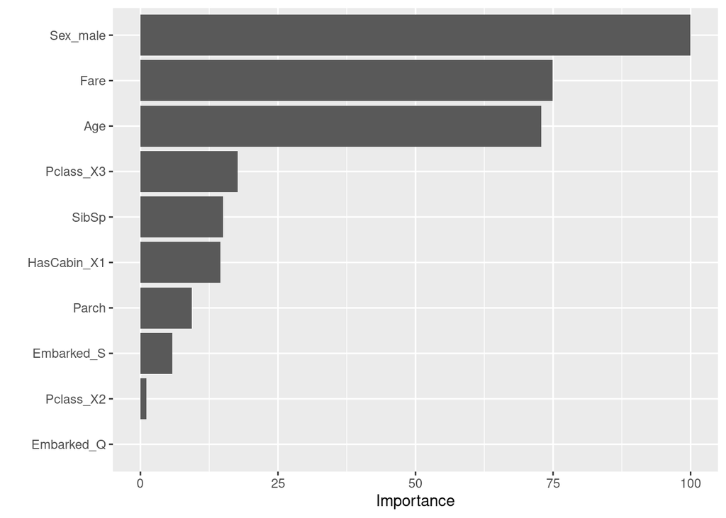

```r
vip(object = rf_cv_titanic, num_features = 10, method = "model")
```

```r
# write R codes here

print(model_summary)
```

```
##                 Model Optimal_ROC Hyperparameter Optimal_Value
## 1 Logistic Regression   0.8587114            N/A            NA
## 2                 KNN   0.8568408              k            13
## 3       Decision Tree   0.8580521             cp             0
## 4       Random Forest   0.8746484           mtry             4
```

```r
print(final_model_titanic)
```

```
##
## Call:
##  randomForest(formula = Survived ~ Pclass + Sex + Age + Fare +      SibSp + Parch + Embarked + HasCabin, data = titanic_train,      mtry = optimal_mtry_rf, importance = TRUE)
##                Type of random forest: classification
##                      Number of trees: 500
## No. of variables tried at each split: 4
##
##         OOB estimate of  error rate: 17.79%
## Confusion matrix:
##     X0  X1 class.error
## X0 385  55   0.1250000
## X1  72 202   0.2627737
```

## Conclusion

The data preprocessing phase meticulously imputed missing values, normalized critical numerical features like Age and Fare, and engineered new features, including HasCabin, to augment the dataset’s predictive capacity.

Beyond predictive performance, this project also emphasized the importance of a systematic machine learning pipeline. Data preprocessing, careful model selection, and hyperparameter optimization were critical in achieving reliable results. The project provided valuable insights into the historical context of the Titanic disaster, illustrating how socioeconomic factors and demographics contributed to survival likelihoods.

In summary, this project not only achieved its goal of building an accurate survival prediction model but also strengthened my understanding of practical machine learning techniques, including data cleaning, feature engineering, model evaluation, and interpretability.